# wrangle_act

## Data Wrangling Project on dog_rate tweets from 2015 - 2017

Import all required libraries for this Analysis

```python
import pandas as pd
import tweepy
from tweepy import OAuthHandler
import json
from timeit import default_timer as timer
import requests
from datetime import datetime as dt
from textblob import TextBlob
import re
import preprocessor as p
from textblob import TextBlob
from wordcloud import WordCloud, STOPWORDS, ImageColorGenerator
import matplotlib.pyplot as plt
% matplotlib inline
```

```
UsageError: Line magic function `%` not found.
```

## Gather Data

Read from csv file

```python
twitter_archive_df = pd.read_csv('twitter-archive-enhanced.csv')
twitter_archive_df.tweet_id.head()
```

```
0    892420643555336193
1    892177421306343426
2    891815181378084864
3    891689557279858688
4    891327558926688256
Name: tweet_id, dtype: int64
```

Download image predictions file and save the file locally

```python
url = 'https://d17h27t6h515a5.cloudfront.net/topher/2017/August/599fd2ad_image-predictions/image-predictions.tsv'
r = requests.get(url)

with open('image-predictions.tsv', 'wb') as file:
    file.write(r.content)

# Retrieve HTTP meta-data
print(r.status_code)
print(r.headers['content-type'])
print(r.encoding)
```

```
200
text/tab-separated-values; charset=utf-8
utf-8
```

```python
image_prediction_df = pd.read_csv('image-predictions.tsv', sep='\t')
image_prediction_df.head()
```

|  | tweet_id | jpg_url | img_num | p1 | p1_conf | p1_dog | p2 | p2_conf | p2_dog | p3 | p3_conf | p3_dog |
| --- | --- | --- | --- | --- | --- | --- | --- | --- | --- | --- | --- | --- |
| 0 | 666020888022790149 | https://pbs.twimg.com/media/CT4udn0WwAA0aMy.jpg | 1 | Welsh_springer_spaniel | 0.465074 | True | collie | 0.156665 | True | Shetland_sheepdog | 0.061428 | True |
| 1 | 666029285002620928 | https://pbs.twimg.com/media/CT42GRgUYAA5iDo.jpg | 1 | redbone | 0.506826 | True | miniature_pinscher | 0.074192 | True | Rhodesian_ridgeback | 0.072010 | True |
| 2 | 666033412701032449 | https://pbs.twimg.com/media/CT4521TWwAEvMyu.jpg | 1 | German_shepherd | 0.596461 | True | malinois | 0.138584 | True | bloodhound | 0.116197 | True |
| 3 | 666044226329800704 | https://pbs.twimg.com/media/CT5Dr8HUEAA-lEu.jpg | 1 | Rhodesian_ridgeback | 0.408143 | True | redbone | 0.360687 | True | miniature_pinscher | 0.222752 | True |
| 4 | 666049248165822465 | https://pbs.twimg.com/media/CT5IQmsXIAAKY4A.jpg | 1 | miniature_pinscher | 0.560311 | True | Rottweiler | 0.243682 | True | Doberman | 0.154629 | True |

Gather additional data from twitter API

```python
#define twitter API credentials
consumer_key = 'HIDDEN'
consumer_secret = 'HIDDEN'
access_token = 'HIDDEN'
access_secret = 'HIDDEN'
```

```python
auth = OAuthHandler(consumer_key, consumer_secret)
auth.set_access_token(access_token, access_secret)

api = tweepy.API(auth, wait_on_rate_limit=True)

# Tweet IDs for which to gather additional data via Twitter's API
tweet_ids = twitter_archive_df.tweet_id.values
len(tweet_ids)

# Query Twitter's API for JSON data for each tweet ID in the Twitter archive
count = 0
fails_dict = {}
start = timer()
#Save each tweet's returned JSON as a new line in a .txt file
with open('tweet_json.txt', 'w') as outfile:
    # This loop will likely take 20-30 minutes to run because of Twitter's rate limit
    for tweet_id in tweet_ids:
        count += 1
        print(str(count) + ": " + str(tweet_id))
        try:
            tweet = api.get_status(tweet_id, tweet_mode='extended')
            print("Success")
            json.dump(tweet._json, outfile)
            outfile.write('\n')
        except tweepy.TweepError as e:
            print("Fail")
            fails_dict[tweet_id] = e
            pass
end = timer()
print(end - start)
print(fails_dict)
```

[output not shown]

[output cut: 198 more lines]

[output not shown]

[output not shown]

[output cut: 32 more lines]

[output not shown]

We now have the tweets in json format. Lets create a dataframe from the json formatted text file.

```python
# define a tweets dictionary
tweet_dict = {}

#define lists to append line data into
tweets, tweet_id, tweet_text,favorite_count,retweet_count,created_at,followers_count,user_likes,hashtags,user_mentions  = [],[],[],[],[],[],[],[],[],[]

#read file line, loop over the lines
with open('tweet_json.txt') as file:

    for tweet in file:
        tweet = json.loads(tweet)
        tweet_id.append(tweet['id'])
        tweet_text.append(tweet['full_text'])
        favorite_count.append(tweet['favorite_count'])
        retweet_count.append(tweet['retweet_count'])
        created_at.append(tweet['created_at'])
        followers_count.append(tweet['user']['followers_count'])
        user_likes.append(tweet['user']['favourites_count'])

        if len(tweet['entities']['hashtags']) != 0:
            hashtags.append(tweet['entities']['hashtags'][0]['text'])
        else:
            hashtags.append('-')
        if len(tweet['entities']['user_mentions']) != 0:
            user_mentions.append(tweet['entities']['user_mentions'][0]['screen_name'])
        else:
            user_mentions.append('-')


tweet_dict = {
            'tweet_id':tweet_id,
            'tweet_text':tweet_text,
            'favorite_count':favorite_count,
            'retweet_count':retweet_count,
            'created_at':created_at,
            'followers_count':followers_count,
            'user_likes':user_likes,
            'hashtags':hashtags,
            'user_mentions':user_mentions
            }

tweet_df = pd.DataFrame(data=tweet_dict)

#save the dictionary into a csv file
tweet_df.to_csv('twitter_archive_master.csv', index=False)
```

We now have all the tweets data saved in **twitter_archive_master.csv**.

We are done with our data gathering.

Lets read from the csv to begin the data Assessment

```python
twitter_master_df = pd.read_csv('twitter_archive_master.csv')
```

## Assess

Make a copy of each dataframe in case we will need the original later in the analysis

```python
tweets = twitter_master_df.copy()
image_predictions = image_prediction_df.copy()
```

In the below lines we will run explolatory analysis programatically.

```python
tweets.info()
```

```
<class 'pandas.core.frame.DataFrame'>
RangeIndex: 2333 entries, 0 to 2332
Data columns (total 9 columns):
tweet_id           2333 non-null int64
tweet_text         2333 non-null object
favorite_count     2333 non-null int64
retweet_count      2333 non-null int64
created_at         2333 non-null object
followers_count    2333 non-null int64
user_likes         2333 non-null int64
hashtags           2333 non-null object
user_mentions      2333 non-null object
dtypes: int64(5), object(4)
memory usage: 164.1+ KB
```

```python
tweets.sample(10)
```

|  | tweet_id | tweet_text | favorite_count | retweet_count | created_at | followers_count | user_likes | hashtags | user_mentions |
| --- | --- | --- | --- | --- | --- | --- | --- | --- | --- |
| 936 | 751456908746354688 | Here's a pupper that's very hungry but too laz... | 3308 | 1039 | Fri Jul 08 16:44:23 +0000 2016 | 8255976 | 142437 | - | - |
| 2179 | 668643542311546881 | Fascinating dog here. Loves beach. Oddly long ... | 871 | 524 | Mon Nov 23 04:13:37 +0000 2015 | 8255998 | 142438 | - | - |
| 101 | 872122724285648897 | This is Kody. He's a baller. Wishes he was a l... | 33340 | 7751 | Tue Jun 06 16:07:15 +0000 2017 | 8255958 | 142437 | - | - |
| 1779 | 676949632774234114 | This is Tyrus. He's a Speckled Centennial Tico... | 1330 | 402 | Wed Dec 16 02:19:04 +0000 2015 | 8255991 | 142437 | - | - |
| 1267 | 708149363256774660 | This is Jebberson. He's the reigning hide and ... | 4387 | 1591 | Fri Mar 11 04:35:39 +0000 2016 | 8255980 | 142437 | - | - |
| 292 | 836001077879255040 | Atlas is back and this time he's prettier than... | 19655 | 4409 | Sun Feb 26 23:52:43 +0000 2017 | 8255960 | 142437 | - | - |
| 2220 | 667902449697558528 | This is Cleopatricia. She is a northern Paperb... | 840 | 371 | Sat Nov 21 03:08:47 +0000 2015 | 8255996 | 142438 | - | - |
| 2189 | 668587383441514497 | Never forget this vine. You will not stop watc... | 1665 | 1059 | Mon Nov 23 00:30:28 +0000 2015 | 8255998 | 142438 | - | - |
| 133 | 865359393868664832 | This is Sammy. Her tongue ejects without warni... | 25944 | 4849 | Fri May 19 00:12:11 +0000 2017 | 8255957 | 142437 | - | - |
| 99 | 872620804844003328 | This is Monkey. She's supporting owners everyw... | 20104 | 3495 | Thu Jun 08 01:06:27 +0000 2017 | 8255959 | 142437 | PrideMonth | - |

```python
sum(tweets.duplicated())
```

```
0
```

```python
sum(tweets.tweet_id.isnull())
```

```
0
```

```python
image_predictions.sample(10)
```

|  | tweet_id | jpg_url | img_num | p1 | p1_conf | p1_dog | p2 | p2_conf | p2_dog | p3 | p3_conf | p3_dog |
| --- | --- | --- | --- | --- | --- | --- | --- | --- | --- | --- | --- | --- |
| 1165 | 735274964362878976 | https://pbs.twimg.com/media/CjQ4radW0AENP-m.jpg | 1 | studio_couch | 0.944692 | False | four-poster | 0.007942 | False | quilt | 0.006302 | False |
| 1400 | 768609597686943744 | https://pbs.twimg.com/media/CqqmWa7WcAAIM-n.jpg | 1 | basenji | 0.183283 | True | Italian_greyhound | 0.136012 | True | whippet | 0.060130 | True |
| 1835 | 837012587749474308 | https://pbs.twimg.com/media/C52pYJXWgAA2BEf.jpg | 1 | toilet_tissue | 0.186387 | False | cowboy_hat | 0.158555 | False | sombrero | 0.149470 | False |
| 1148 | 731156023742988288 | https://pbs.twimg.com/media/CiWWhVNUYAAab_r.jpg | 1 | lakeside | 0.501767 | False | breakwater | 0.051351 | False | king_penguin | 0.049444 | False |
| 570 | 678396796259975168 | https://pbs.twimg.com/media/CWomSU_XIAAUYiK.jpg | 2 | Pembroke | 0.956180 | True | Cardigan | 0.031803 | True | Chihuahua | 0.006276 | True |
| 1150 | 732005617171337216 | https://pbs.twimg.com/media/CiibOMzUYAA9Mxz.jpg | 1 | English_setter | 0.677408 | True | Border_collie | 0.052724 | True | cocker_spaniel | 0.048572 | True |
| 440 | 674447403907457024 | https://pbs.twimg.com/media/CVweVUfW4AACPwI.jpg | 1 | Brabancon_griffon | 0.409909 | True | malinois | 0.244649 | True | bull_mastiff | 0.074820 | True |
| 908 | 700505138482569216 | https://pbs.twimg.com/media/Cbixs3vUUAAqHHN.jpg | 1 | bath_towel | 0.449684 | False | Norwegian_elkhound | 0.160205 | True | Great_Dane | 0.048666 | True |
| 1811 | 832998151111966721 | https://pbs.twimg.com/media/C49nZavUYAEJjGw.jpg | 1 | boxer | 0.539036 | True | French_bulldog | 0.317617 | True | bull_mastiff | 0.093928 | True |
| 368 | 672968025906282496 | https://pbs.twimg.com/media/CVbc2V2WsAE3-kn.jpg | 1 | toy_poodle | 0.678046 | True | miniature_poodle | 0.160273 | True | Airedale | 0.065649 | True |

```python
image_predictions.info()
```

```
<class 'pandas.core.frame.DataFrame'>
RangeIndex: 2075 entries, 0 to 2074
Data columns (total 12 columns):
tweet_id    2075 non-null int64
jpg_url     2075 non-null object
img_num     2075 non-null int64
p1          2075 non-null object
p1_conf     2075 non-null float64
p1_dog      2075 non-null bool
p2          2075 non-null object
p2_conf     2075 non-null float64
p2_dog      2075 non-null bool
p3          2075 non-null object
p3_conf     2075 non-null float64
p3_dog      2075 non-null bool
dtypes: bool(3), float64(3), int64(2), object(4)
memory usage: 152.1+ KB
```

```python
sum(image_predictions.duplicated())
```

```
0
```

### Assessment Comments

After both visual and programatic analysis on the data, below are the comments that we will clean later

#### Quality

*tweets*

- The created_at column is a string
- The created_at column date is of an API format
- Missing hashtag information
- hashtag is a float data type column
- missing user_mentions data
- retweets are included
- Tweet text includes hashtags, mentions, ratings and other non-alphabetical characters

*image predictions*

- Breed dogs names separated by an underscore and in lowercase
- 6 decimal places for model prediction scores
- Columns have inappropriate names

#### Tidiness

*tweets*

- Ratings are included within the tweet_text column

*image predictions*

- first, second and third prediction data are included together in the same table

## Clean

#### Quality of data

**Tweets**

- The created_at column is a string
- The created_at column date is of an API format

*Define*

Convert created at column to a datetime format and convert the date to datetime

*Code*

```python
#convert into date time
tweets['created_at'] = pd.to_datetime(tweets['created_at'], format='%a %b %d %H:%M:%S +%f %Y')
```

*Test*

```python
tweets['created_at'].head(3)
```

```
0   2017-08-01 16:23:56
1   2017-08-01 00:17:27
2   2017-07-31 00:18:03
Name: created_at, dtype: datetime64[ns]
```

**Tweets**

- Missing hashtag information
- hashtag is a float data type column

*Define*

Extract all hashtags from the tweet text fields

*Code*

```python
tweets['hashtags'] = tweets['tweet_text'].str.extractall(r"#(\w+)").unstack().apply(lambda x:' '.join(x.dropna()), axis=1)
```

*Test*

```python
tweets.iloc[2129]['hashtags']
```

```
'NoDaysOff swole'
```

**Tweets**

- missing user_mentions data

*Define*

*Code*

```python
tweets['hashtags'] = tweets['tweet_text'].str.extractall(r"@(\w+)").unstack().apply(lambda x:' '.join(x.dropna()), axis=1)
```

*Test*

```python
tweets.iloc[29]['user_mentions']
```

```
'NonWhiteHat'
```

**Tweets**

- retweets are included

*Define*

Filter out all retweets into a retweet dataframe

*Code*

```python
tweets[tweets['tweet_text'].str.startswith("RT")]['tweet_text'].count()
```

```
167
```

```python
#filter all retweets into a different retweet dataframe
retweets_df = tweets[tweets['tweet_text'].str.startswith("RT")]
```

```python
#filter out all retweets
tweets = tweets[~tweets['tweet_text'].str.startswith("RT")]
```

*Test*

```python
retweets_df.head(3)
```

|  | tweet_id | tweet_text | favorite_count | retweet_count | created_at | followers_count | user_likes | hashtags | user_mentions |
| --- | --- | --- | --- | --- | --- | --- | --- | --- | --- |
| 31 | 886054160059072513 | RT @Athletics: 12/10 #BATP https://t.co/WxwJmv... | 0 | 104 | 2017-07-15 02:45:48 | 8255958 | 142437 | Athletics | Athletics |
| 35 | 885311592912609280 | RT @dog_rates: This is Lilly. She just paralle... | 0 | 17482 | 2017-07-13 01:35:06 | 8255958 | 142437 | dog_rates | dog_rates |
| 67 | 879130579576475649 | RT @dog_rates: This is Emmy. She was adopted t... | 0 | 6445 | 2017-06-26 00:13:58 | 8255959 | 142437 | dog_rates | dog_rates |

```python
tweets[tweets['tweet_text'].str.startswith("RT")]['tweet_text'].count()
```

```
0
```

**Tweets**

- Tweet text includes hashtags, mentions, ratings and other non-alphabetical characters

*Define*

Clean up the tweet text- remove hashtags, mentions, ratings and any other non-alphabetical characters

*Code*

function definition that will do our text cleaning for us

```python
def clean_tweet_text(text):
    #remove user mentions and hashtags
    clean_text = re.sub(r"@(\w+)",'', str(text))
    clean_text = re.sub(r"#(\w+)",'',clean_text)

    #remove dog names - Tweets introduce names using 'This is', 'Meet', 'Say hello to'
    clean_text = re.sub(r"This is (\w+).|Meet (\w+).| Say hello to (\w+).",'',clean_text)

    #remove any url in the tweet
    clean_text = re.sub(r'(?i)\b((?:https?://|www\d{0,3}[.]|[a-z0-9.\-]+[.][a-z]{2,4}/)(?:[^\s()<>]+|\(([^\s()<>]+|(\([^\s()<>]+\)))*\))+(?:\(([^\s()<>]+|(\([^\s()<>]+\)))*\)|[^\s`!()\[\]{};:\'".,<>?«»“”‘’]))', '', clean_text)

    #removing any other punctuation or any other non-alphabetical characters
    clean_text = re.sub(r"[.,;:$&*|?'-]",' ',clean_text)
    clean_text = re.sub(r"(\d+/\d+)",'',clean_text)

    return clean_text
```

Apply the function to tweet_text column and save the clean text to clean_text new column

```python
tweets['clean_text'] = tweets['tweet_text'].apply(clean_tweet_text)
```

*Test*

```python
print(tweets.iloc[2129]['tweet_text'], '\n', tweets.iloc[2129]['clean_text'])
```

```
This is Scout. She is a black Downton Abbey. Isn't afraid to get dirty. 9/10 nothing bad to say https://t.co/kH60oka1HW
  She is a black Downton Abbey  Isn t afraid to get dirty   nothing bad to say
```

**image predictions**

- Breed dogs names separated by an underscore and in lowercase

*Define*

Remove the underscore and capitalize the first name

*Code*

```python
image_predictions['p1'] = image_predictions['p1'].str.capitalize().str.replace('_', ' ')
image_predictions['p2'] = image_predictions['p2'].str.capitalize().str.replace('_', ' ')
image_predictions['p3'] = image_predictions['p3'].str.capitalize().str.replace('_', ' ')
```

*Test*

```python
image_predictions['p3'].sample(3)
```

```
1995    Toy poodle
1320     Tiger cat
879          Boxer
Name: p3, dtype: object
```

**image predictions**

- 6 decimal places for model prediction scores

*Define*

Convert into a percentage and a whole number and convert into integer

*Code*

```python
image_predictions['p1_conf'] = round(image_predictions['p1_conf']*100).astype(int)
image_predictions['p2_conf'] = round(image_predictions['p2_conf']*100).astype(int)
image_predictions['p3_conf'] = round(image_predictions['p3_conf']*100).astype(int)
```

*Test*

```python
image_predictions['p3_conf'].sample(3)
```

```
674      0
588     12
1965     0
Name: p3_conf, dtype: int32
```

**image predictions**

- Columns have inappropriate names

*Define*

Rename columns

*Code*

```python
image_predictions.columns.values
```

```
array(['tweet_id', 'jpg_url', 'img_num', 'p1', 'p1_conf', 'p1_dog', 'p2',
       'p2_conf', 'p2_dog', 'p3', 'p3_conf', 'p3_dog'], dtype=object)
```

```python
image_predictions.rename(columns={"jpg_url": "image_url",
                                  "img_num" : "image_number",
                                  "p1": "p01_dogname",
                                  "p1_conf": "p01_confidence",
                                  "p1_dog": "p01_isbreed",
                                  "p2": "p02_dogname",
                                  "p2_conf": "p02_confidence",
                                  "p2_dog": "p02_isbreed",
                                  "p3": "p03_dogname",
                                  "p3_conf": "p03_confidence",
                                  "p3_dog": "p03_isbreed"}  , inplace=True)
```

*Test*

```python
image_predictions.columns.values
```

```
array(['tweet_id', 'image_url', 'image_number', 'p01_dogname',
       'p01_confidence', 'p01_isbreed', 'p02_dogname', 'p02_confidence',
       'p02_isbreed', 'p03_dogname', 'p03_confidence', 'p03_isbreed'],
      dtype=object)
```

#### Tidiness

**Tweets**

- Ratings are included in the tweet_text column

*Define*

Separate ratings from tweet_text column and calculate the actual rating

*Code*

Define a function to calculate dog rating

```python
def calculate_rating(rating):

    if rating:
        rated = int(rating.split('/')[0])
        rated_out_of = int(rating.split('/')[1])

        #catch division by 0 error
        try:
            calculated_rating = int((rated/rated_out_of)*100)
        except ZeroDivisionError:
            calculated_rating = 0

        return calculated_rating
    else:
        return 0
```

```python
#Extract the rating from tweet text
tweets['rating'] = tweets.tweet_text.str.extract(r"(\d+/\d+)", expand = True)

#calculate rating
tweets['rating'] = tweets['rating'].apply(calculate_rating)
```

*Test*

```python
tweets['rating'].sample(3)
```

```
978    100
771    120
925    110
Name: rating, dtype: int64
```

```python
#Extract image urls from the tweet_text
tweets['image_url'] = tweets['tweet_text'].str.extractall(r'(?i)\b((?:https?://|www\d{0,3}[.]|[a-z0-9.\-]+[.][a-z]{2,4}/)(?:[^\s()<>]+|\(([^\s()<>]+|(\([^\s()<>]+\)))*\))+(?:\(([^\s()<>]+|(\([^\s()<>]+\)))*\)|[^\s`!()\[\]{};:\'".,<>?«»“”‘’]))').unstack().apply(lambda x:' '.join(x.dropna()), axis=1)
tweets['image_url'].head(5)
```

```
0    https://t.co/MgUWQ76dJU
1    https://t.co/0Xxu71qeIV
2    https://t.co/wUnZnhtVJB
3    https://t.co/tD36da7qLQ
4    https://t.co/AtUZn91f7f
Name: image_url, dtype: object
```

**image predictions**

- first, second and third prediction data are included together in the same table

*Define*

Seprate first, second and third prediction into different data frames to form 3 indepedent observational units

*Code*

```python
image_predictions01 = image_predictions[['tweet_id','image_url', 'image_number','p01_dogname', 'p01_confidence', 'p01_isbreed']]
image_predictions02 = image_predictions[['tweet_id', 'image_url', 'image_number','p02_dogname', 'p02_confidence', 'p02_isbreed']]
image_predictions03 = image_predictions[['tweet_id', 'image_url', 'image_number','p03_dogname', 'p03_confidence', 'p03_isbreed']]
```

```python
image_predictions03.head(3)
```

|  | tweet_id | image_url | image_number | p03_dogname | p03_confidence | p03_isbreed |
| --- | --- | --- | --- | --- | --- | --- |
| 0 | 666020888022790149 | https://pbs.twimg.com/media/CT4udn0WwAA0aMy.jpg | 1 | Shetland sheepdog | 6 | True |
| 1 | 666029285002620928 | https://pbs.twimg.com/media/CT42GRgUYAA5iDo.jpg | 1 | Rhodesian ridgeback | 7 | True |
| 2 | 666033412701032449 | https://pbs.twimg.com/media/CT4521TWwAEvMyu.jpg | 1 | Bloodhound | 12 | True |

Drop all unneccesarry columns

```python
tweets_clean = tweets.drop(['tweet_text'], axis=1)
tweets_clean.head(1)
```

|  | tweet_id | favorite_count | retweet_count | created_at | followers_count | user_likes | hashtags | user_mentions | clean_text | rating | image_url |
| --- | --- | --- | --- | --- | --- | --- | --- | --- | --- | --- | --- |
| 0 | 892420643555336193 | 37293 | 7987 | 2017-08-01 16:23:56 | 8255958 | 142437 | NaN | - | He s a mystical boy Only ever appears in the... | 130 | https://t.co/MgUWQ76dJU |

Finally lets save all cleaned datasets

```python
image_predictions01.to_csv('cleaned_datasets/image_predictions01.csv', index=False)
image_predictions02.to_csv('cleaned_datasets/image_predictions02.csv', index=False)
image_predictions03.to_csv('cleaned_datasets/image_predictions03.csv', index=False)
tweets_clean.to_csv('cleaned_datasets/clean_tweets.csv', index=False)
```

## Insights and Visualization

**1. Whats is the general feeling about dogs?**

*We will do a sentiment analysis to answer the above question*

define sentiment analysis function using TextBlob library

```python
def analyze_sentiment(tweet):
    analysis = TextBlob(tweet)
    if analysis.sentiment.polarity > 0:
        return 'Positive'
    elif analysis.sentiment.polarity == 0:
        return 'Neutral'
    else:
        return 'Negative'
```

Apply the analyze sentiment function to clean text column

```python
tweets['tweet_sentiment'] = tweets['clean_text'].apply(analyze_sentiment)
```

```python
sentiment = tweets.groupby('tweet_sentiment').count().tweet_id
```

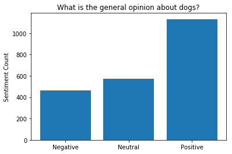

```python
# Create a bar chart with proper labels
locations = [1,2,3]
heights = [sentiment[0], sentiment[1],sentiment[2]]
labels = ['Negative', 'Neutral', 'Positive']
plt.bar(locations, heights, tick_label=labels)
plt.title('What is the general opinion about dogs?')
# plt.xlabel('Sentiment Category')
plt.ylabel('Sentiment Count');
```

**2. Whats is the tweet trend over the years from 2015 to 2017?**

Calculate the tweet year and month, we ll use this 2 columns to sort the trend values

```python
tweets['created_year'] = tweets['created_at'].dt.year
tweets['created_month'] = tweets['created_at'].dt.month
```

```python
tweets['created_year_month'] = tweets['created_at'].dt.strftime('%b-%Y')
```

```python
tweets_trend = tweets[['tweet_id','created_year', 'created_month','created_year_month']].groupby(['created_year', 'created_month','created_year_month']).count().tweet_id.reset_index()
t_trend = pd.DataFrame(data = tweets_trend)
```

Plot a line graph to show the tweet trend over time. A line graph is the best visual to shown progress over time

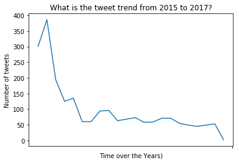

```python
plt.plot(t_trend.created_year_month,t_trend.tweet_id)
plt.title('What is the tweet trend from 2015 to 2017?')
plt.xlabel('Time over the Years)')
plt.ylabel('Number of tweets')
plt.xticks('','')
plt.show()
```

There is a clear drop in the number of tweets over the years 2015 to 2017

**3. Which Dog breed is the most and least rated?**

To answer the above question we will merge 3 data frames; tweets ratings, image_predictions01, image_predictions02 and image_predictions03

```python
#get all ratings for dogs in tweets data
rated = tweets[['tweet_id','rating']].sort_values(['rating'],ascending=False)
```

**Which image prediction has the best probable outcome?**

Calculate the mean confidence for the image prediction. We will use the highest prediction to determine our dog breed

```python
print('Mean Confidence for prediction 01: {}'.format(round(image_predictions01.p01_confidence.mean())))
print('Mean Confidence for prediction 02: {}'.format(round(image_predictions02.p02_confidence.mean())))
print('Mean Confidence for prediction 03: {}'.format(round(image_predictions03.p03_confidence.mean())))
```

```
Mean Confidence for prediction 01: 59
Mean Confidence for prediction 02: 13
Mean Confidence for prediction 03: 6
```

**Prediction 01** has the highest prediction mean.

```python
dog_rated = pd.merge(rated, image_predictions01,on=['tweet_id'], how='left')
dogs_breed = dog_rated[dog_rated['p01_isbreed']==True][['rating', 'p01_dogname']]
```

```python
dogs_breed.head(5)
```

|  | rating | p01_dogname |
| --- | --- | --- |
| 5 | 750 | Pomeranian |
| 6 | 342 | Golden retriever |
| 7 | 270 | Clumber |
| 8 | 260 | Kuvasz |
| 15 | 140 | Bedlington terrier |

The **Pomeranian** is the highest rated dog breed with a *750%* rate followed by the **Golden Retriever** with a *342%* rating

```python
dogs_breed.tail(5)
```

|  | rating | p01_dogname |
| --- | --- | --- |
| 2130 | 30 | Afghan hound |
| 2135 | 30 | Chihuahua |
| 2139 | 30 | Pug |
| 2149 | 20 | Maltese dog |
| 2151 | 20 | Great dane |

The **Maltese dog** and **Great dane** are the least rated dogs with a *20%* rating

**4. What are the most mentioned words?**

We are going to create a word cloud from the cleaned text column.

```python
#combine the clean text into 1 big text chunk
text = " ".join(cleantext for cleantext in tweets.clean_text)
```

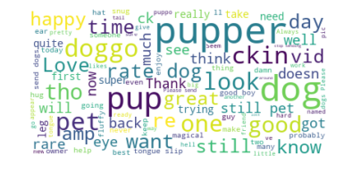

```python
stopwords = set(STOPWORDS)
#filter out introductory and vulgar words
stopwords.update(["say", "hello",'af'])
# Generate a word cloud
wordcloud = WordCloud(stopwords=stopwords,max_font_size=50, max_words=100, background_color="white").generate(text)
plt.figure()
plt.imshow(wordcloud, interpolation="bilinear")
plt.axis("off")
plt.show()
```

Most of the dogs are referred to as *pupper / pup / doggo*

There is a positive feeling towards dogs as they are described as happy, great, rare and slightly magical.

### References

- https://stackoverflow.com/questions/55223093/pandas-finding-the-exact-word-and-before-word-in-a-column-of-string-and-append-t
- https://www.datacamp.com/community/tutorials/wordcloud-python
- https://textblob.readthedocs.io/en/dev/